# Final Project: NYPD Shooting Incident Data Report

Daekyum Kim

June/6/2021

# *Table of Contents*

- Introduction
- Step 1. Create Markdown
- Step 2. Cleaning Data
- Step 3. Visualizing and Modeling Data
  - 3.1 Monthly Fatality Cases
  - 3.2 Simple Model for Fatalities
  - 3.3 Distribution of Fatalities by District
- Step 4. Bias Identification & Conclusion

## **Introduction**

In this report, I wanted to analyze the NYPD Shooting Incident data with tools

I was able to find and use the historic NYPD Shooting Incident data dating between year 2006 and 2020.

With materials covered in the lecture, I performed clean up, visualization and modeling of the data.

## **Step 1. Create Markdown**

As the first step, I loaded up the tidyverse package.

Loaded tidyverse using *library(tidyverse)*

## **Step 2. Cleaning Data**

```r
# Load in the dataset

url_in <- "https://data.cityofnewyork.us/api/views/833y-fsy8/rows.csv?accessType=DOWNLOAD"

nypd_shooting <- read_csv(url_in)
summary(nypd_shooting)
```

```
##   INCIDENT_KEY        OCCUR_DATE         OCCUR_TIME           BORO
##  Min.   :  9953245   Length:23568       Length:23568      Length:23568
##  1st Qu.: 55317014   Class :character   Class1:hms        Class :character
##  Median : 83365370   Mode  :character   Class2:difftime   Mode  :character
##  Mean   :102218616                      Mode  :numeric
##  3rd Qu.:150772442
##  Max.   :222473262
##
##     PRECINCT      JURISDICTION_CODE LOCATION_DESC      STATISTICAL_MURDER_FLAG
##  Min.   :  1.00   Min.   :0.0000    Length:23568       Mode :logical
##  1st Qu.: 44.00   1st Qu.:0.0000    Class :character   FALSE:19080
##  Median : 69.00   Median :0.0000    Mode  :character   TRUE :4488
##  Mean   : 66.21   Mean   :0.3323
##  3rd Qu.: 81.00   3rd Qu.:0.0000
##  Max.   :123.00   Max.   :2.0000
##                   NA's   :2
##  PERP_AGE_GROUP       PERP_SEX          PERP_RACE         VIC_AGE_GROUP
##  Length:23568       Length:23568       Length:23568       Length:23568
##  Class :character   Class :character   Class :character   Class :character
##  Mode  :character   Mode  :character   Mode  :character   Mode  :character
##
##
##
##
##    VIC_SEX            VIC_RACE           X_COORD_CD        Y_COORD_CD
##  Length:23568       Length:23568       Min.   : 914928   Min.   :125757
##  Class :character   Class :character   1st Qu.: 999900   1st Qu.:182565
##  Mode  :character   Mode  :character   Median :1007645   Median :193482
##                                        Mean   :1009363   Mean   :207312
##                                        3rd Qu.:1016807   3rd Qu.:239163
##                                        Max.   :1066815   Max.   :271128
##
##     Latitude       Longitude        Lon_Lat
##  Min.   :40.51   Min.   :-74.25   Length:23568
##  1st Qu.:40.67   1st Qu.:-73.94   Class :character
##  Median :40.70   Median :-73.92   Mode  :character
##  Mean   :40.74   Mean   :-73.91
##  3rd Qu.:40.82   3rd Qu.:-73.88
##  Max.   :40.91   Max.   :-73.70
##
```

There are 23568 entries with 19 columns in this dataframe.

```r
# Change column names to lower cases

names(nypd_shooting) <- tolower(names(nypd_shooting))

# Change type of Occur_Date from characters to time date

nypd_shooting$occur_date = as.Date(nypd_shooting$occur_date, format = "%m/%d/%Y")

# Dropping x_coord_cd, y_coord_cd, latitude, longitude as they are redundant.

nypd_shooting <- nypd_shooting[, -c(15:18)]

# Change some column names to clarify

# Change BORO to district & statistical_murder_flag to is_murder

colnames(nypd_shooting)[4] <- "district"

colnames(nypd_shooting)[8] <- "is_murder"

# Then look how many entries are na

cbind(lapply(lapply(nypd_shooting, is.na), sum))
```

```
##                   [,1]
## incident_key      0
## occur_date        0
## occur_time        0
## district          0
## precinct          0
## jurisdiction_code 2
## location_desc     13581
## is_murder         0
## perp_age_group    8459
## perp_sex          8425
## perp_race         8425
## vic_age_group     0
## vic_sex           0
## vic_race          0
## lon_lat           0
```

There are five columns with missing entries:

1. jurisdiction_code
2. location_desc
3. perp_age_group
4. perp_sex
5. perp_race

I will dive deeper to see if I can fill in those na entries column by column

```r
# Rows with missing jurisdiction_code

nypd_shooting[is.na(nypd_shooting$jurisdiction_code), ]
```

```
## # A tibble: 2 x 15
##   incident_key occur_date occur_time district  precinct jurisdiction_code
##          <dbl> <date>     <time>     <chr>        <dbl>             <dbl>
## 1    194525846 2019-03-09 02:41      MANHATTAN       25                NA
## 2     33110745 2007-07-13 01:10      QUEENS         104                NA
## # ... with 9 more variables: location_desc <chr>, is_murder <lgl>,
## #   perp_age_group <chr>, perp_sex <chr>, perp_race <chr>, vic_age_group <chr>,
## #   vic_sex <chr>, vic_race <chr>, lon_lat <chr>
```

```r
# Retrieve jurisdiction_code for precinct 25 and 104

view(nypd_shooting[nypd_shooting$precinct == 25, ])

# Unclear whether jurisdiction_code is 0 or 2. Will remove the entry.

view(nypd_shooting[nypd_shooting$precinct == 104, ])

# Clearly every column with precinct 104 has jurisdiction_code 0 so fill it in

nypd_shooting$jurisdiction_code[is.na(nypd_shooting$jurisdiction_code) == 1 & nypd_shooting$precinct == 104] <- 0

# Dropping row with precinct 25 and missing jurisdiction_code
nypd_shooting2 <- drop_na(nypd_shooting, jurisdiction_code)

cbind(lapply(lapply(nypd_shooting2, is.na), sum))
```

```
##                   [,1]
## incident_key      0
## occur_date        0
## occur_time        0
## district          0
## precinct          0
## jurisdiction_code 0
## location_desc     13580
## is_murder         0
## perp_age_group    8459
## perp_sex          8425
## perp_race         8425
## vic_age_group     0
## vic_sex           0
## vic_race          0
## lon_lat           0
```

```r
# Cleaned up the jurisdiction_code. Off to next column: location_desc

# Unable to tell why location_desc is na
nypd_shooting2[is.na(nypd_shooting2$location_desc) == 1, ]
```

```
## # A tibble: 13,580 x 15
##    incident_key occur_date occur_time district  precinct jurisdiction_code
##           <dbl> <date>     <time>     <chr>        <dbl>             <dbl>
##  1    201575314 2019-08-23 22:10      QUEENS         103                 0
##  2    205748546 2019-11-27 15:54      BRONX           40                 0
##  3    193118596 2019-02-02 19:40      MANHATTAN       23                 0
##  4    201483468 2019-08-22 18:03      BRONX           46                 0
##  5    198255460 2019-06-07 17:50      BROOKLYN        73                 0
##  6    194570529 2019-03-11 16:30      BROOKLYN        81                 0
##  7    199582060 2019-07-10 02:56      BROOKLYN        69                 0
##  8    204464564 2019-11-04 13:40      BRONX           40                 0
##  9    205908100 2019-12-02 11:50      BROOKLYN        67                 0
## 10    197953462 2019-06-01 14:14      QUEENS         101                 0
## # ... with 13,570 more rows, and 9 more variables: location_desc <chr>,
## #   is_murder <lgl>, perp_age_group <chr>, perp_sex <chr>, perp_race <chr>,
## #   vic_age_group <chr>, vic_sex <chr>, vic_race <chr>, lon_lat <chr>
```

```r
# Investigate what values are in location_desc column
unique(nypd_shooting2$location_desc)
```

```
##  [1] NA                          "PVT HOUSE"
##  [3] "MULTI DWELL - APT BUILD"   "MULTI DWELL - PUBLIC HOUS"
##  [5] "GROCERY/BODEGA"            "GAS STATION"
##  [7] "FAST FOOD"                 "BAR/NIGHT CLUB"
##  [9] "COMMERCIAL BLDG"           "SOCIAL CLUB/POLICY LOCATI"
## [11] "HOSPITAL"                  "SUPERMARKET"
## [13] "LIQUOR STORE"              "HOTEL/MOTEL"
## [15] "RESTAURANT/DINER"          "SHOE STORE"
## [17] "DRUG STORE"                "NONE"
## [19] "DRY CLEANER/LAUNDRY"       "BEAUTY/NAIL SALON"
## [21] "STORE UNCLASSIFIED"        "SMALL MERCHANT"
## [23] "DEPT STORE"                "FACTORY/WAREHOUSE"
## [25] "CLOTHING BOUTIQUE"         "VARIETY STORE"
## [27] "JEWELRY STORE"             "TELECOMM. STORE"
## [29] "CHAIN STORE"               "CANDY STORE"
## [31] "VIDEO STORE"               "GYM/FITNESS FACILITY"
## [33] "ATM"                       "SCHOOL"
## [35] "PHOTO/COPY STORE"          "BANK"
## [37] "LOAN COMPANY"              "STORAGE FACILITY"
## [39] "CHECK CASH"                "DOCTOR/DENTIST"
```

```r
# Decided to replace na with unspecified
nypd_shooting2$location_desc <- replace_na(nypd_shooting2$location_desc, "unspecified")

# See if there's any missing values
sum(is.na(nypd_shooting2$location_desc))
```

```
## [1] 0
```

Columns with na:

*TABLE*

| Columns | # Na | Unique Entries |
| --- | --- | --- |
| perp_sex | 8425 | NA, M, F, U |
| perp_race | 8425 | NA, BLACK, WHITE HISPANIC, BLACK HISPANIC, UNKNOWN, WHITE, ASIAN / PACIFIC ISLANDER, AMERICAN INDIAN/ALASKAN NATIVE |
| perp_age_group | 8459 | NA, <18, 18-24, 25-44, 45-64, UNKNOWN, 65+, 1020, 940, 224 |

There are same number of na entries for columns perp_sex and perp_race. I suspect those entries are identical. There are 34 more entries with na for column perp_age_group. Those will require further inspection to ensure.

```r
# Check how many rows are there with na in columns perp_sex & perp_race & perp_age_group
nrow(nypd_shooting2[is.na(nypd_shooting2$perp_sex) & is.na(nypd_shooting2$perp_race) & is.na(nypd_shooting2$perp_age_group), ])
```

```
## [1] 8425
```

```r
# Before going further as there are 34 more rows with perp_age_group, I want to see if these are all part of unknown

# so perp_sex & perp_race != na and perp_age_group = na
nypd_shooting2[!is.na(nypd_shooting2$perp_sex) & !is.na(nypd_shooting2$perp_race) & is.na(nypd_shooting2$perp_age_group), ]
```

```
## # A tibble: 34 x 15
##    incident_key occur_date occur_time district      precinct jurisdiction_code
##           <dbl> <date>     <time>     <chr>            <dbl>             <dbl>
##  1     10333338 2006-02-05 12:50      QUEENS             102                 0
##  2     10879217 2006-04-02 03:47      MANHATTAN           33                 0
##  3     10187488 2006-01-16 07:53      BRONX               40                 0
##  4     10879217 2006-04-02 03:47      MANHATTAN           33                 0
##  5     10454364 2006-02-15 11:45      STATEN ISLAND      120                 0
##  6     10333338 2006-02-05 12:50      QUEENS             102                 0
##  7     16631430 2006-05-18 20:16      BROOKLYN            67                 0
##  8     10953928 2006-04-08 02:35      QUEENS             113                 0
##  9     10454369 2006-02-16 02:25      BROOKLYN            73                 0
## 10     10333334 2006-02-05 00:25      BROOKLYN            94                 0
## # ... with 24 more rows, and 9 more variables: location_desc <chr>,
## #   is_murder <lgl>, perp_age_group <chr>, perp_sex <chr>, perp_race <chr>,
## #   vic_age_group <chr>, vic_sex <chr>, vic_race <chr>, lon_lat <chr>
```

```r
# And I see that every rows are with unknowns for other two columns so I can write these entries with "UNKNOWN"

# As suspected those are in same entries. Investigate what are unique entries for these columns (matches total na = 8425)
unique(nypd_shooting2$perp_sex)
```

```
## [1] NA  "M" "F" "U"
```

```r
unique(nypd_shooting2$perp_race)
```

```
## [1] NA                               "BLACK"
## [3] "WHITE HISPANIC"                 "BLACK HISPANIC"
## [5] "UNKNOWN"                        "WHITE"
## [7] "ASIAN / PACIFIC ISLANDER"       "AMERICAN INDIAN/ALASKAN NATIVE"
```

```r
unique(nypd_shooting2$perp_age_group)
```

```
##  [1] NA        "<18"     "18-24"   "25-44"   "45-64"   "UNKNOWN" "65+"
##  [8] "1020"    "940"     "224"
```

```r
# Replace na with "U", "UNKNOWN", "UNKNOWN" for perp_sex, perp_race and perp_age_group
nypd_shooting2$perp_sex <- replace_na(nypd_shooting2$perp_sex, "U")
nypd_shooting2$perp_race <- replace_na(nypd_shooting2$perp_race, "UNKONWN")
nypd_shooting2$perp_age_group <- replace_na(nypd_shooting2$perp_age_group, "UNKONWN")


cbind(lapply(lapply(nypd_shooting2, is.na), sum))
```

```
##                   [,1]
## incident_key      0
## occur_date        0
## occur_time        0
## district          0
## precinct          0
## jurisdiction_code 0
## location_desc     0
## is_murder         0
## perp_age_group    0
## perp_sex          0
## perp_race         0
## vic_age_group     0
## vic_sex           0
## vic_race          0
## lon_lat           0
```

```r
# Give the dataframe new name
nypd_clean <- nypd_shooting2
```

## **Step 3. Visualizing and Modeling Data**

### **3.1 Monthly Fatality Cases**

As a first visualization, I wanted to see if there’s any trend in monthly fatality cases as time passed by.

```r
library(dplyr)
library(lubridate)
```

```r
# Plot 1. Monthly Fatality cases



# daily table
nypd_plot1 <- nypd_clean %>%
 group_by(occur_date) %>%
 summarize(total_murder = sum(is_murder))

# Monthly table
monthly <- nypd_plot1 %>%
           mutate(month = month(occur_date), year = year(occur_date)) %>%
          group_by(year, month) %>%
           summarize(monthly_murder = sum(total_murder))
# For plot X axis
monthly$year_month <- with(monthly, sprintf("%d-%02d", year, month))

monthly
```

```
## # A tibble: 180 x 4
## # Groups:   year [15]
##     year month monthly_murder year_month
##    <dbl> <dbl>          <int> <chr>
##  1  2006     1             29 2006-01
##  2  2006     2             27 2006-02
##  3  2006     3             14 2006-03
##  4  2006     4             37 2006-04
##  5  2006     5             40 2006-05
##  6  2006     6             36 2006-06
##  7  2006     7             47 2006-07
##  8  2006     8             46 2006-08
##  9  2006     9             44 2006-09
## 10  2006    10             38 2006-10
## # ... with 170 more rows
```

```
## geom_path: Each group consists of only one observation. Do you need to adjust
## the group aesthetic?
```

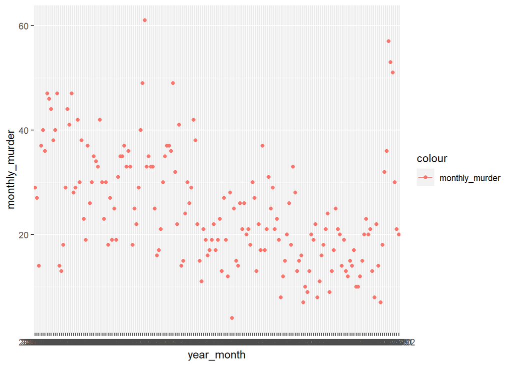

```r
# Visualization
monthly %>%
 filter(monthly_murder > 0) %>%
ggplot(aes(x = year_month, y = monthly_murder)) +
 geom_line(aes(color = "monthly_murder")) +
 geom_point(aes(color = "monthly_murder"))
```

Upon inspecting the graph, I see downward trends in number of fatality cases reported every month.

I wanted to put together a simple linear regression model to see if district and vic_age_group has any impact on this downward trend to shooting fatalities.

### **3.2 Simple Model for Fatalities**

```r
mod <- lm(is_murder ~ district + vic_age_group, data = nypd_clean)

summary(mod)
```

```
##
## Call:
## lm(formula = is_murder ~ district + vic_age_group, data = nypd_clean)
##
## Residuals:
##     Min      1Q  Median      3Q     Max
## -0.3470 -0.2220 -0.1657 -0.1302  0.8879
##
## Coefficients:
##                        Estimate Std. Error t value Pr(>|t|)
## (Intercept)            0.124575   0.008679  14.354  < 2e-16 ***
## districtBROOKLYN       0.005663   0.006208   0.912   0.3617
## districtMANHATTAN     -0.012498   0.008667  -1.442   0.1493
## districtQUEENS         0.007277   0.008137   0.894   0.3712
## districtSTATEN ISLAND  0.014532   0.015547   0.935   0.3499
## vic_age_group18-24     0.035417   0.008806   4.022 5.79e-05 ***
## vic_age_group25-44     0.091803   0.008688  10.567  < 2e-16 ***
## vic_age_group45-64     0.126813   0.012652  10.023  < 2e-16 ***
## vic_age_group65+       0.207897   0.032342   6.428 1.32e-10 ***
## vic_age_groupUNKNOWN   0.118558   0.049092   2.415   0.0157 *
## ---
## Signif. codes:  0 '***' 0.001 '**' 0.01 '*' 0.05 '.' 0.1 ' ' 1
##
## Residual standard error: 0.3908 on 23557 degrees of freedom
## Multiple R-squared:   0.01,  Adjusted R-squared:  0.009627
## F-statistic: 26.45 on 9 and 23557 DF,  p-value: < 2.2e-16
```

It shows there is statistical significance between vic_age_group(s) and fatalities. Of course there are more factors that would be leading to

less fatalities, such as systemic improvements in first respondents and medical cares but those are not provided in our data.

### **3.3 Distribution of Fatalities by District**

I want to see what percentage of shooting incidents lead to fatality

```r
sum(nypd_clean$is_murder)
```

```
## [1] 4488
```

```r
perc_fatality <- sum(nypd_clean$is_murder) / 23567 * 100

perc_fatality
```

```
## [1] 19.04358
```

There are 4,488 cases that led to fatalities out of 23,567 total shooting incidents.

That is about 19%

As a second visualization, I wanted to further inspect how it is distributed among districts.

```r
# Plot 2. Visualize % of murders in each districts
nypd_plot2 <- nypd_clean %>%
group_by(district) %>%
summarize(num_murders = sum(is_murder))

# Calculate %
nypd_plot2$pct <- nypd_plot2$num_murders / sum(nypd_plot2$num_murders) * 100

nypd_plot2
```

```
## # A tibble: 5 x 3
##   district      num_murders   pct
##   <chr>               <int> <dbl>
## 1 BRONX                1244 27.7
## 2 BROOKLYN             1892 42.2
## 3 MANHATTAN             512 11.4
## 4 QUEENS                697 15.5
## 5 STATEN ISLAND         143  3.19
```

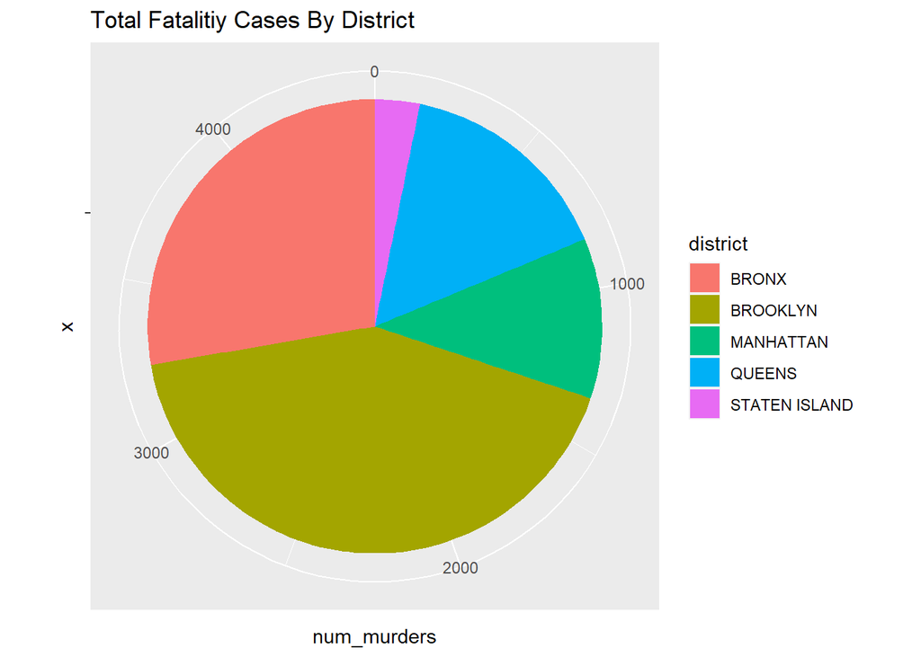

```r
# Bargraph first
bp<- ggplot(nypd_plot2, aes(x="", y=num_murders, fill=district))+
     geom_bar(width = 1, stat = "identity")

pie <- bp + coord_polar("y", start = 0) + labs(title = "Total Fatalitiy Cases By District")

pie
```

Brooklyn and Bronx were two districts with largest share of fatality cases.

These two visualizations raised additional questions that I should investigate:

1. In first visualization, there were some outliers. What was the cause for the spike in number of fatal shooting reports?
2. In second visualization, What makes Brooklyn and Bronx take up largest shares of fatality cases?

With given data, it is hard to answer those questions. With granular data, I might be able to answer these follow up questions or I could research on my own to answer those questions.

## **Step 4. Bias Identification & Conclusion**

Based on the visualizations and data analysis, I can conclude monthly fatalities in shooting incidents are in downward trend.

Also large portion of fatalities cases are reported in Bronx and Brooklyn.

My personal bias for the reason is probably because Bronx and Brooklyn have active gang activities. In order to mitigate this bias, I would need detailed demography data to make sure I have reasonable backing from data.

```r
osVersion
```

```
## [1] "Windows 10 x64 (build 19042)"
```